# Exploratory Data Analysis: Zebrafish Larval Behaviour Assay - Wildtype NR4A vs. NR4A Knockouts (2)

Jory Curry

# Behavioural Analysis Report – inadur

## Background

Zebrafish larvae are pipetted into 96-Well plates. There is one experiment included in the data set, with 2 NR4A Knockouts and one Wildtype genotype. There are 48 wildtype (24 - WTa, 24 - WTb) biological replicates and 24 of each gene knockout group (24 - NR4Aa, 24 - NR4Ab) – A total of 96 biological samples.

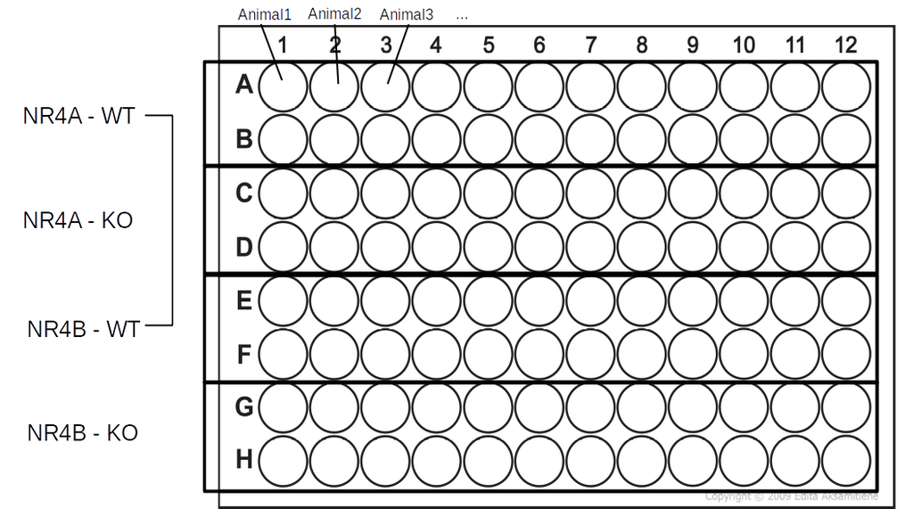

The behavioural data is collected using an infrared camera over a 50-minute period where the first 20 minutes allow the zebrafish embryos to acclimate to their environment, and for the next 30 minutes there are 5-minute cycles of light and darkness – 96-well plate format. Zebrafish naturally tend to be more active in the dark.

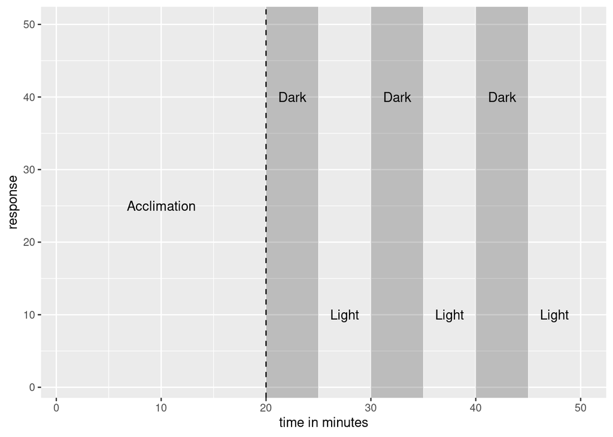

Figure 3. A visual representation of the behavioural assay protocol

The infrared camera traces the swim paths of fish during the entire experiment. A one-minute snapshot of raw swim paths look like this:

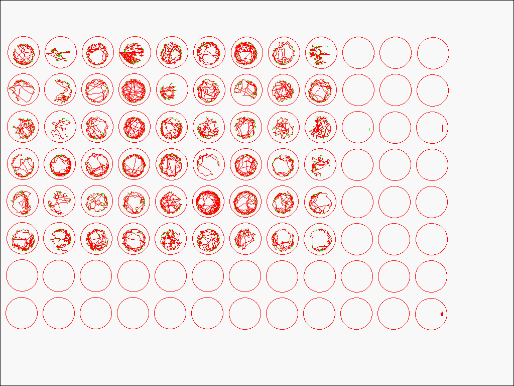

Figure 4. An example of what the raw swim-path tracing looks like from the Viewpoint Zebrabox infrared camera and Viewpoint Zebralab software

The raw data contain many variables that we will explore once we import the data. You can browse the meta data in the next section of this report.

## Directory & Meta Data

.XLS files have been converted to .csv files and are included in the directory /home/joryc/NR4A2_Zebrafish_Light_Dark_Behavioural_Response/Data. These are the raw data files that this EDA will be using.

| Animal | Treatment | Genotype | Subtype |
| --- | --- | --- | --- |
| Animal01 | nr4a-wt1 | WT | NA |
| Animal02 | nr4a-wt2 | WT | NA |
| Animal03 | nr4a-wt3 | WT | NA |
| Animal04 | nr4a-wt4 | WT | NA |
| Animal05 | nr4a-wt5 | WT | NA |
| Animal06 | nr4a-wt6 | WT | NA |
| Animal07 | nr4a-wt7 | WT | NA |
| Animal08 | nr4a-wt8 | WT | NA |
| Animal09 | nr4a-wt9 | WT | NA |
| Animal10 | nr4a-wt10 | WT | NA |
| Animal11 | nr4a-wt11 | WT | NA |
| Animal12 | nr4a-wt12 | WT | NA |
| Animal13 | nr4a-wt13 | WT | NA |
| Animal14 | nr4a-wt14 | WT | NA |
| Animal15 | nr4a-wt15 | WT | NA |
| Animal16 | nr4a-wt16 | WT | NA |
| Animal17 | nr4a-wt17 | WT | NA |
| Animal18 | nr4a-wt18 | WT | NA |
| Animal19 | nr4a-wt19 | WT | NA |
| Animal20 | nr4a-wt20 | WT | NA |
| Animal21 | nr4a-wt21 | WT | NA |
| Animal22 | nr4a-wt22 | WT | NA |
| Animal23 | nr4a-wt23 | WT | NA |
| Animal24 | nr4a-wt24 | WT | NA |
| Animal25 | nr4a-ko1 | KO | nr4a2a |
| Animal26 | nr4a-ko2 | KO | nr4a2a |
| Animal27 | nr4a-ko3 | KO | nr4a2a |
| Animal28 | nr4a-ko4 | KO | nr4a2a |
| Animal29 | nr4a-ko5 | KO | nr4a2a |
| Animal30 | nr4a-ko6 | KO | nr4a2a |

[output cut: 66 more lines]

## Importing the raw data files & taking a glimpse

Glimpse the raw data to see the structure of each variable, the number of observations and the class of the `raw_data` object

```
## Rows: 9,790
## Columns: 16
## $ animal    <chr> "Animal01", "Animal01", "Animal02", "Animal02", "Animal03", …
## $ Treatment <chr> "nr4a-wt1", "nr4a-wt1", "nr4a-wt2", "nr4a-wt2", "nr4a-wt3", …
## $ an        <lgl> FALSE, TRUE, FALSE, TRUE, FALSE, TRUE, FALSE, TRUE, FALSE, T…
## $ start     <dbl> 0, 0, 0, 0, 0, 0, 0, 0, 0, 0, 0, 0, 0, 0, 0, 0, 0, 0, 0, 0, …
## $ end       <dbl> 60, 60, 60, 60, 60, 60, 60, 60, 60, 60, 60, 60, 60, 60, 60, …
## $ inact     <int> 69, 69, 97, 97, 56, 56, 64, 64, 73, 73, 77, 77, 75, 75, 56, …
## $ inadur    <dbl> 36.7, 36.7, 11.2, 11.2, 9.6, 9.6, 15.4, 15.4, 22.1, 22.1, 8.…
## $ inadist   <dbl> 0, 0, 0, 0, 0, 0, 0, 0, 0, 0, 0, 0, 0, 0, 0, 0, 0, 0, 0, 0, …
## $ smlct     <int> 88, 88, 261, 261, 353, 353, 172, 172, 180, 180, 202, 202, 23…
## $ smldur    <dbl> 22.1, 22.1, 25.2, 25.2, 25.4, 25.4, 39.1, 39.1, 32.5, 32.5, …
## $ smldist   <dbl> 320.3, 320.3, 432.6, 432.6, 945.7, 945.7, 719.1, 719.1, 603.…
## $ larct     <int> 20, 20, 118, 118, 385, 385, 122, 122, 130, 130, 145, 145, 20…
## $ lardur    <dbl> 1.1, 1.1, 9.3, 9.3, 24.4, 24.4, 5.3, 5.3, 5.1, 5.1, 5.5, 5.5…
## $ lardist   <dbl> 31.9, 31.9, 466.0, 466.0, 1163.7, 1163.7, 161.5, 161.5, 168.…
## $ emptyct   <int> 0, 0, 191, 0, 11, 0, 2, 0, 10, 0, 0, 0, 2, 0, 8, 0, 43, 0, 5…
## $ emptydur  <dbl> 0.0, 0.0, 14.3, 0.0, 0.5, 0.0, 0.1, 0.0, 0.4, 0.0, 0.0, 0.0,…
## [1] "spec_tbl_df" "tbl_df"      "tbl"         "data.frame"
```

From the glimpse it can be seen that there are 16 variables in the tibble/data frame:

## Investigating `raw_data`

### Checking expectations

#### Number of observations/rows

It is expected that the raw data will have 4800 rows because there are 96 wells, and the assay is 50 minutes

```r
nrow(raw_data)
## [1] 9790
```

However, there are 9790 rows present in the raw data. This expectation was violated because each observation is duplicated and there are some extra observations

| Treatment | an | end | smldist | lardist | emptyct | emptydur |
| --- | --- | --- | --- | --- | --- | --- |
| nr4a-wt1 | FALSE | 60 | 320.3 | 31.9 | 0 | 0.0 |
| nr4a-wt1 | TRUE | 60 | 320.3 | 31.9 | 0 | 0.0 |
| nr4a-wt2 | FALSE | 60 | 432.6 | 466.0 | 191 | 14.3 |
| nr4a-wt2 | TRUE | 60 | 432.6 | 466.0 | 0 | 0.0 |
| nr4a-wt3 | FALSE | 60 | 945.7 | 1163.7 | 11 | 0.5 |
| nr4a-wt3 | TRUE | 60 | 945.7 | 1163.7 | 0 | 0.0 |

By looking at just the head of `raw_data`, it can be seen that the variable `an` has a `TRUE` and `FALSE` row for each individual observation. The only difference between these duplicate rows is that the `FALSE` rows retain information about `emptyct` and `emptydur`.

```r
raw_data <- raw_data %>%
  filter(an == FALSE) %>% # Removing duplicate rows
  select(-c(an)) # This variable is not very useful anymore, so removing
nrow(raw_data)
## [1] 4895
```

After filtering for just the false values, there are now 4895 rows. There are 95 extra observations in `raw_data` because there are some extra observations past 50 minutes.

```r
raw_data <- raw_data %>%
  filter(end <= 3000) # Deleting observations past 50 mins (3000 seconds)
nrow(raw_data)
## [1] 4800
identical(as.numeric(nrow(raw_data)), (96 * 50 * 1)) # is the expected number of rows consistent with the observed number of rows after processing?
## [1] TRUE
```

After ensuring there are no observations past the 50-minute mark, there are now 4800 rows, as expected.

#### Variable Distributions & Outliers

Quick visualizations of the distributions of each variable are a fast and easy way to learn a lot about the data such as the range, distribution of observations, and outliers.  
First, the ‘counts’ variable distributions will be investigated.

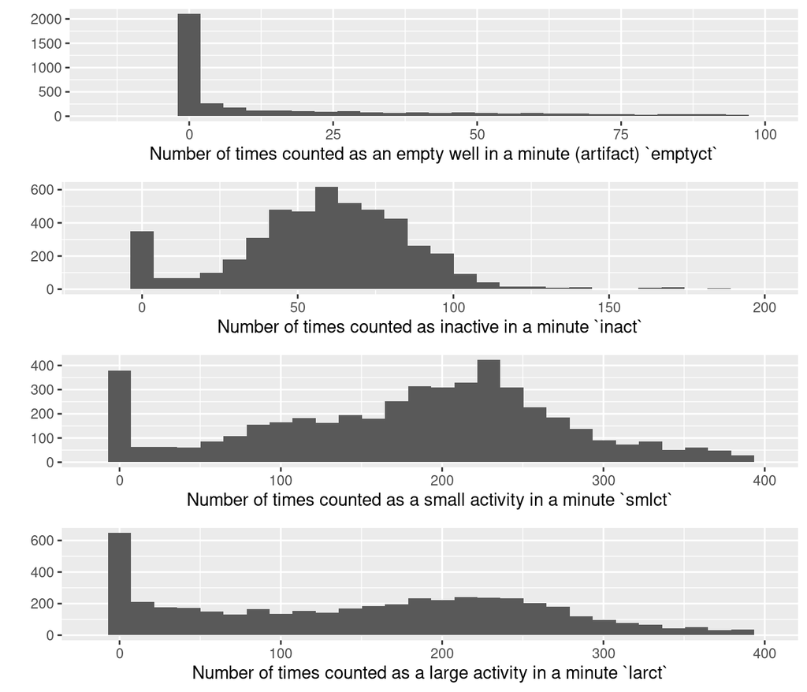

Figure 5. Quick plots of the ‘counts’ variables in the `raw_data` object

Figure 5 (plot 1) shows that there are some artifacts in the data. Sometimes, the camera/software was not able to detect a fish even though, there certainly were fish in those wells. The `emptyct` variable (plot 1) is a good tool to use for flagging observations that need to transformed to `NA`s in the next section (Suspicious Values).  
It can be seen that the amount of times an animal goes inactive during an observation period (`inact`) is approximately ~60 times per minute on average. As well, it can be seen that small swim bursts (`smlct`) tend to occur just over 225 times per minute on average. And finally, we can see that large swim bursts (`larct`) can either occur just over 200 times per minute, or 0 times per minute. This could be due to sensitive effects of light on swim inhibition, or darkness stimulating large swim behaviours.  
The distributions of all count variables are slightly skewed, with few outliers, except for the empty well counts which are very positively skewed.  
Next, the ‘duration’ variable distributions will be explored. Note: this variable should never exceed 60 seconds.

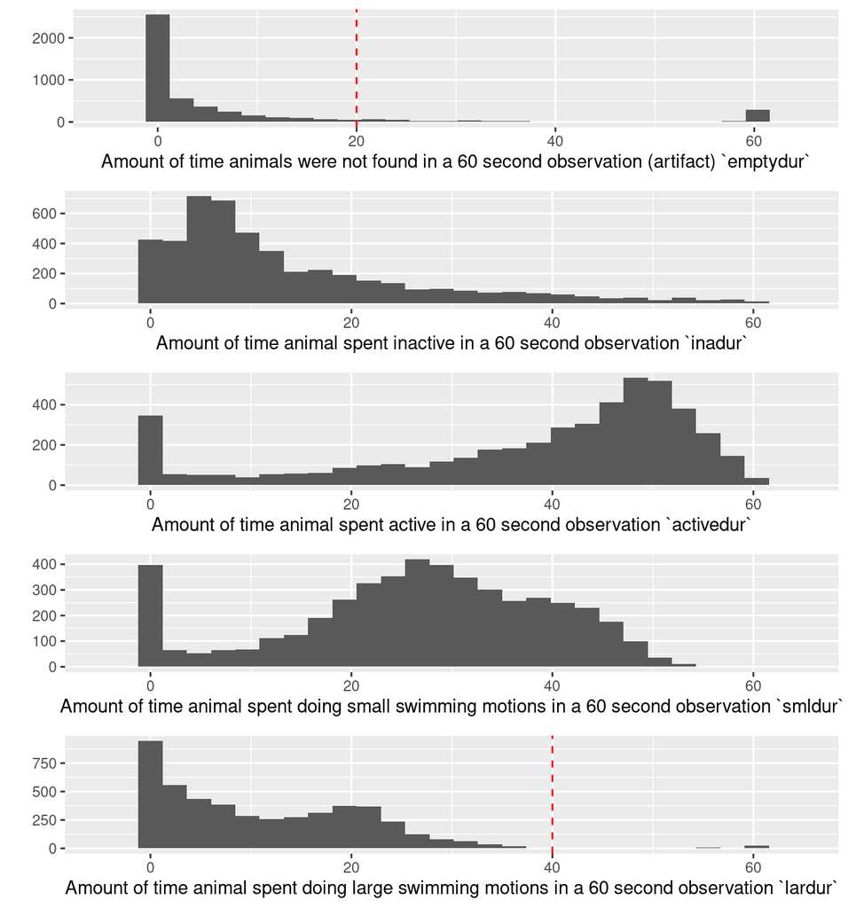

Figure 6. Quick plots of the ‘duration’ variables in the `raw_data` object

Figure 6 reveals another red flag with the `emptydur` variable (plot 1 in figure 6). There are some observations that show 60 full seconds of being empty! This is likely more than just an artifact in the recording instrument/software. These are likely dead or immobile fish that never moved at all so the infrared camera was never able to start tracing their swim patterns (during that 60-second observation period). However, it can also be seen that there are some observations greater than 0 and less than 60 in this plot. In theory, if an animal is present in the well, the `emptydur` value should always be zero. An arbitrary threshold of 20 seconds of empty duration will be used to transform all observations (across variables) with an `emptydur` > 20 into `NA`s  
Again, it can also be seen that the distributions of observations for each variable is slightly skewed. Note also that `inadur` and `activedur` (plots 2 and 3 from figure 6) are approximately inversely related as expected. The emerging pattern of large swim activity duration (`lardur`) clustering around two modes (0s and ~20s) can be observed, similar to the counts variable.

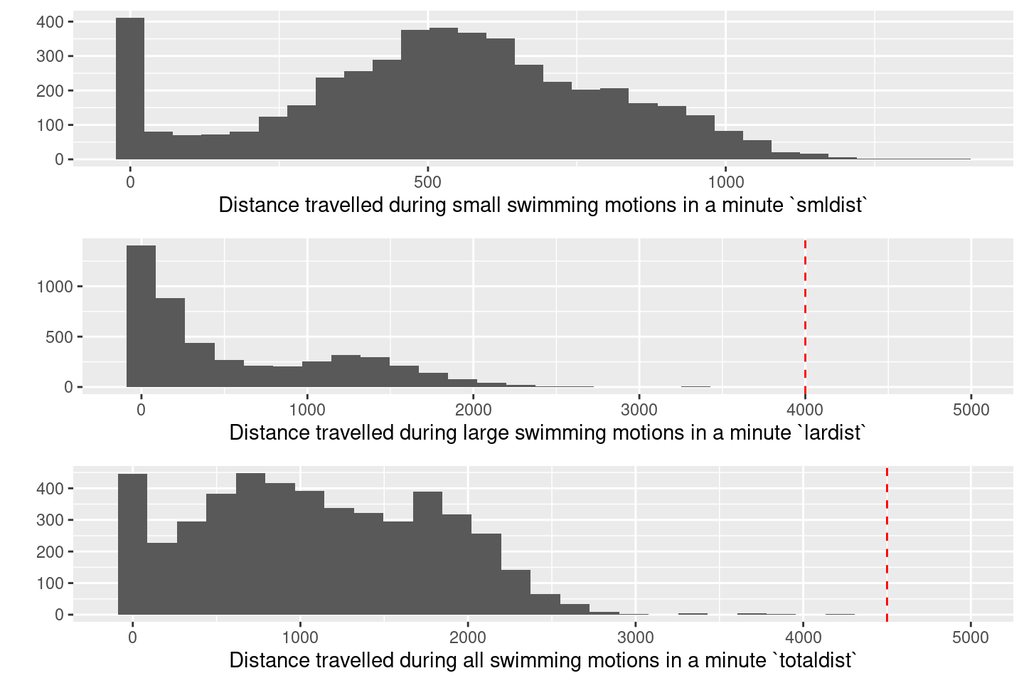

Figure 7. Quick plots of the ‘distance’ variable in the `raw_data` object

Figure 7 shows that the distributions of of the ‘distance’ variables are slightly skewed with the `totaldist` variable being the most normally distributed. Notably, `totaldist` seems to be a promising effect endpoint to analyse since it is the most normally distributed of all the other effect endpoints.

### Evaluating Data Quality

Figure 6 showed that the `emptydur` variable can be used reliably to filter out observations with poor data quality. The ‘empty duration’ variable ranges from 0s to 60s and indicates how long the observation was not able to detect a fish in the well. An arbitrary cutoff value of 20 seconds will be used to determine if an observation was of poor-quality and therefore, should be converted to `NA`. By doing this, the confidence in the accuracy of observations can be increased across the entire data set.

```r
NAObservations <- raw_data %>%
  filter(poorQual == TRUE) %>% # Filter only rows with poor quality that have behavioural endpoint observations turned to NAs
  nrow()
NAObservations
## [1] 620
```

620 60-second observations (rows) were transformed to `NA`s across all of the behavioural endpoint observation variables.  
Overall, the animal recording set-up had an approximate failure-rate of 13 % – the percentage of time the infrared camera failed to detect an animal when it was present in a well.

## Exploring & Visualizing

### ggplots

#### Bar Graphs

Table 2 - ANOVA test p-values after FDR adjustment, comparing effects of different genotypes on inadur for each light cycle

|  | Df | Sum_Sq | Mean_Sq | F_Value | P_value | is_sig |
| --- | --- | --- | --- | --- | --- | --- |
| Light_1_Genotype | 2 | 3118.003 | 1559.00166 | 8.265880 | 2.99e-04 | TRUE |
| Light_1_Residuals | 440 | 82987.019 | 188.60686 | NA | NA | NA |
| Dark_1_Genotype | 2 | 2526.263 | 1263.13174 | 15.078999 | 4.70e-07 | TRUE |
| Dark_1_Residuals | 427 | 35768.769 | 83.76761 | NA | NA | NA |
| Light_2_Genotype | 2 | 1893.900 | 946.95001 | 6.267511 | 2.06e-03 | TRUE |
| Light_2_Residuals | 457 | 69047.529 | 151.08869 | NA | NA | NA |
| Dark_2_Genotype | 2 | 5644.459 | 2822.22934 | 26.218821 | 1.66e-11 | TRUE |
| Dark_2_Residuals | 457 | 49192.098 | 107.64135 | NA | NA | NA |
| Light_3_Genotype | 2 | 8912.009 | 4456.00455 | 26.103190 | 1.96e-11 | TRUE |
| Light_3_Residuals | 436 | 74428.374 | 170.70728 | NA | NA | NA |
| Dark_3_Genotype | 2 | 6177.097 | 3088.54841 | 25.175484 | 4.36e-11 | TRUE |
| Dark_3_Residuals | 447 | 54838.315 | 122.68080 | NA | NA | NA |

##### Plots Binned by individual 5-minute cycles

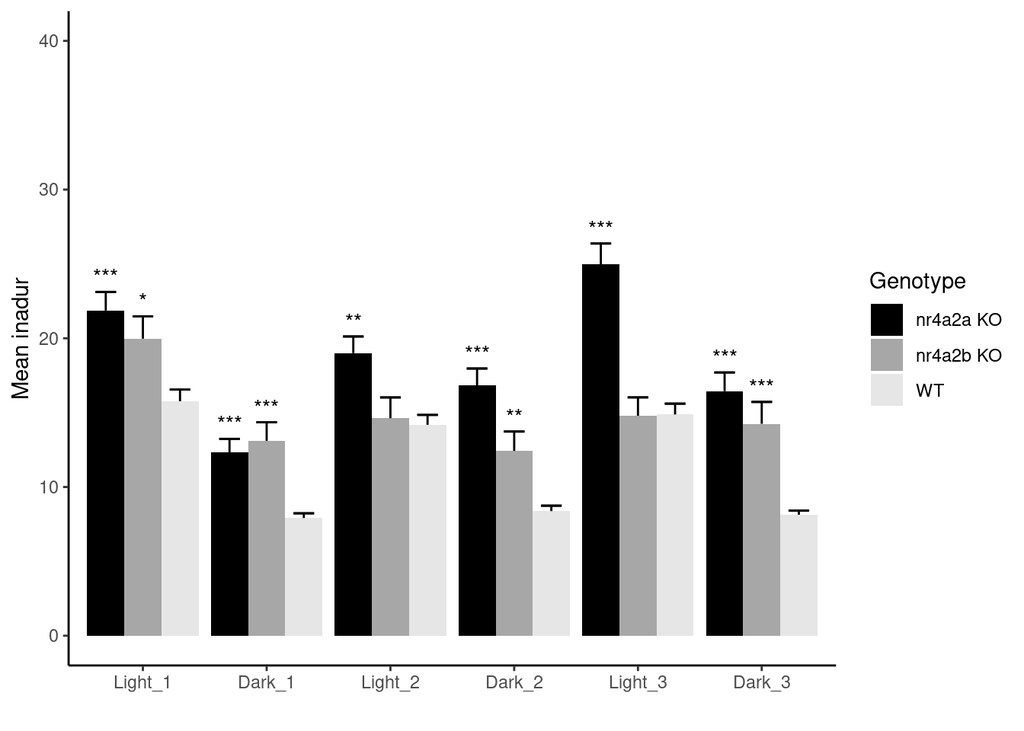

Figure 8. The effect of genotype on behavioural response variable binned by individual 5-minute-long light and dark cycles

Table 3 - ANOVA test p-values after FDR adjustment, comparing effects of different genotypes on inadur for each light cycle

|  | Df | Sum_Sq | Mean_Sq | F_Value | P_value | is_sig |
| --- | --- | --- | --- | --- | --- | --- |
| Light_Genotype | 2 | 11430.12 | 5715.0579 | 33.14578 | 8.91e-15 | TRUE |
| Light_Residuals | 1339 | 230872.88 | 172.4219 | NA | NA | NA |
| Dark_Genotype | 2 | 13359.54 | 6679.7695 | 63.17887 | 6.05e-27 | TRUE |
| Dark_Residuals | 1337 | 141358.20 | 105.7279 | NA | NA | NA |

##### Plots Binned by cycle type (light or dark - 2 bins - 15mins each)

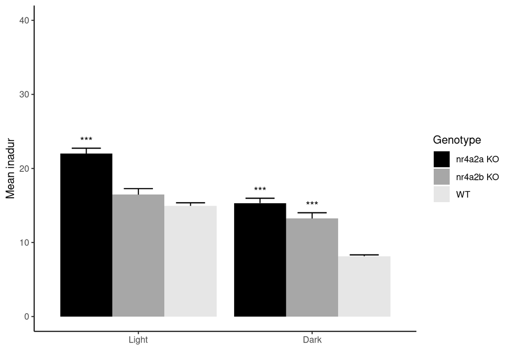

##### Not-binned

Table 4 - ANOVA test p-values after FDR adjustment, comparing effects of different genotypes on inadur

|  | Df | Sum_Sq | Mean_Sq | F_Value | P_value | is_sig |
| --- | --- | --- | --- | --- | --- | --- |
| Genotype | 2 | 23041.61 | 11520.803 | 77.7629 | 1.49e-33 | TRUE |
| Residuals | 2679 | 396901.77 | 148.153 | NA | NA | NA |

##### Plots Not Binned by cycle

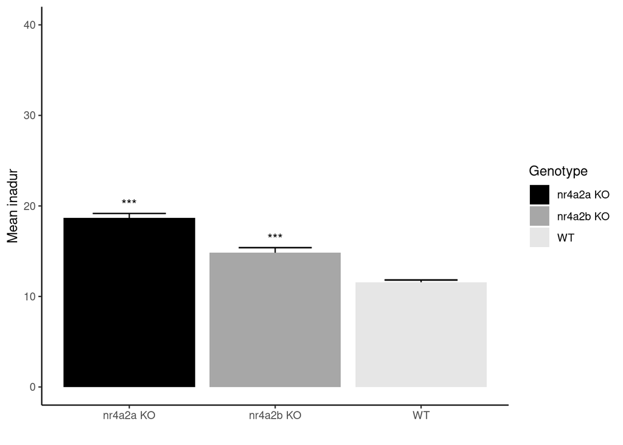

### Trace Paths

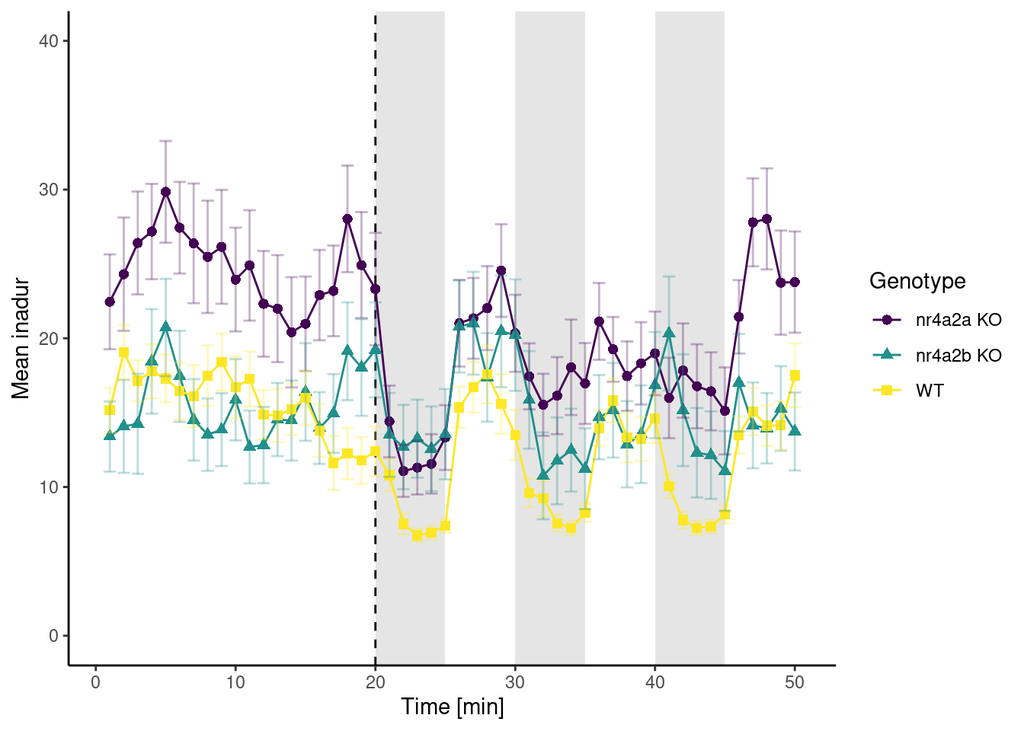

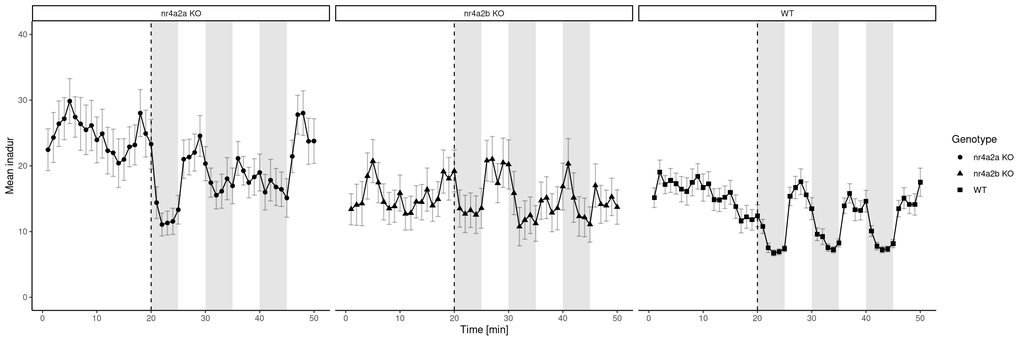